# Day_001_HW

## 練習時間

#### 請寫一個函式用來計算 Mean Square Error

$ MSE = \frac{1}{n}\sum_{i=1}^{n}{(Y_i - \hat{Y}_i)^2} $

### Hint: [如何取平方](https://googoodesign.gitbooks.io/-ezpython/unit-1.html)

# [作業目標]

- 仿造範例的MAE函數, 自己寫一個MSE函數(參考上面公式)

# [作業重點]

- 注意程式的縮排
- 是否能將數學公式, 轉換為 Python 的函式組合? (In[2], Out[2])

```python
# 載入基礎套件與代稱
import numpy as np
import matplotlib.pyplot as plt
```

```python
# 定義 mean_absolute_error 這個函數, 計算並傳回 MAE
def mean_absolute_error(y, yp):
    """
    計算 MAE
    Args:
        - y: 實際值
        - yp: 預測值
    Return:
        - mae: MAE
    """
    mae = MAE = sum(abs(y - yp)) / len(y)
    return mae

# Here is my job
# 定義 mean_squared_error 這個函數, 計算並傳回 MSE
def mean_squared_error(y, yp):
    mse = sum( (y - yp)**2 ) / len(y)
    return mse
```

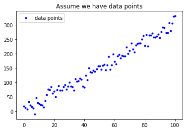

```python
# 與範例相同, 不另外解說
w = 3
b = 0.5
x_lin = np.linspace(0, 100, 101)
y = (x_lin + np.random.randn(101) * 5) * w + b

plt.plot(x_lin, y, 'b.', label = 'data points')
plt.title("Assume we have data points")
plt.legend(loc = 2)
plt.show()
```

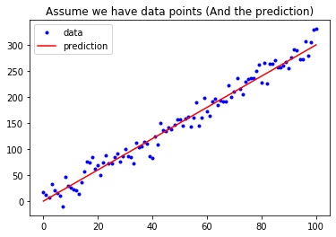

```python
# 與範例相同, 不另外解說
y_hat = x_lin * w + b
plt.plot(x_lin, y, 'b.', label = 'data')
plt.plot(x_lin, y_hat, 'r-', label = 'prediction')
plt.title("Assume we have data points (And the prediction)")
plt.legend(loc = 2)
plt.show()
```

```python
# 執行 Function, 確認有沒有正常執行
MSE = mean_squared_error(y, y_hat)
MAE = mean_absolute_error(y, y_hat)
print("The Mean squared error is %.3f" % (MSE))
print("The Mean absolute error is %.3f" % (MAE))
```

```
The Mean squared error is 213.452
The Mean absolute error is 11.619
```

# [作業2]

請上 Kaggle, 在 Competitions 或 Dataset 中找一組競賽或資料並寫下：

1. 你選的這組資料為何重要
2. 資料從何而來 (tips: 譬如提供者是誰、以什麼方式蒐集)
3. 蒐集而來的資料型態為何
4. 這組資料想解決的問題如何評估

# [ANS2]

我選擇了 [New York City Airbnb Open Data](https://www.kaggle.com/dgomonov/new-york-city-airbnb-open-data) 這筆資料 (可以直接點選連結到該資料集)

1. 因為他可以讓我們知道紐約不同地區背包客的住房需求
2. 提供者為Dgomonov, 是屬於Airbnb的公開數據集
3. CSV檔，包含很多欄位
4. 可以根據地區做熱力圖，就可以知道哪些地區很多背包客喜歡住

# [作業3]

想像你經營一個自由載客車隊，你希望能透過數據分析以提升業績，請你思考並描述你如何規劃整體的分析/解決方案：

1. 核心問題為何 (tips：如何定義 「提升業績 & 你的假設」)
2. 資料從何而來 (tips：哪些資料可能會對你想問的問題產生影響 & 資料如何蒐集)
3. 蒐集而來的資料型態為何
4. 你要回答的問題，其如何評估 (tips：你的假設如何驗證)

# [ANS3]

1. 提升業績 : 增加載客量，縮短路程，把正在待機的車子停放在顯眼的位置(廣告效果) 我的假設 : 鬧區的客人雖多，但計程車載客要排隊，不如打把主力放在長期的客戶身上
2. 可以蒐集客人的上下車資訊，和每天的塞車狀況
3. GPS位置訊息，圖片(客人長相)
4. 可以大概根據蒐集的訊息，來預測等等這位客人是不是要叫車了